# SD_12_RECO_EXP_ADD_L4AB

Investment expenses not included on Form 990 Part 8 line 7b plus other amounts included on Form 990 Part 9 line 25 but not line 1 · Amount report

## Overview

**Description**

Total amounts; add lines 4a through 4b

**Table**

`SD-P12-T00-RECONCILIATION-EXPENSES` (one)

**Location code**

`SCHED-D-PART-12-LINE-04C`

**Family**

`SCHED-D-PART-12-LINE-04C`

**Data type**

numeric (xsd: USAmountType, )

**Scope**

PC

**Status**

unreviewed

4

xpaths mapped (3 observed)

1,011,194

filings with a value

2009–2024

tax years observed

5

open flags (4 errors)

## Flags

| Severity | Flag | Xpath | Detail |
| --- | --- | --- | --- |
| ⚠ error | `COLLISION` | IRS990ScheduleD/ExpensesNotRptdOnFinStmt | 142765 filings contain 2+ of its xpaths; most common set: /Return/ReturnData/IRS990ScheduleD/ExpensesNotRptdOnFinStmt ; /Return/ReturnData/IRS990ScheduleD/RevenueNotRptdOnFinStmt |
| ⚠ error | `POLARITY` | IRS990ScheduleD/ExpensesNotRptFinclStmtAmt | negated element ‘ExpensesNotRptFinclStmtAmt’ pooled with non-negated xpaths |
| ⚠ error | `POLARITY` | IRS990ScheduleD/RevenueNotRptdOnFinStmt | negated element ‘RevenueNotRptdOnFinStmt’ pooled with non-negated xpaths |
| ⚠ error | `POLARITY` | IRS990ScheduleD/ExpensesNotRptdOnFinStmt | negated element ‘ExpensesNotRptdOnFinStmt’ pooled with non-negated xpaths |
| ⓘ info | `UNOBSERVED` | IRS990ScheduleD/Form990ScheduleDPartXIII/TotalAmountsLine4aTo4b | never observed in TY2009-2024 filings |

## Xpaths

All mapped xpaths (under /Return/ReturnData or /Return/ReturnHeader), oldest first. Charts label each series by its xpath.

| Xpath | Form | Chart label | First year | Last year | Versions | Filings | Repeats in |
| --- | --- | --- | --- | --- | --- | --- | --- |
| IRS990ScheduleD/RevenueNotRptdOnFinStmt | Sched D | same | 2009 | 2012 | 18 | 146,897 | 0.0% |
| IRS990ScheduleD/ExpensesNotRptdOnFinStmt | Sched D | same | 2009 | 2012 | 18 | 146,277 | 0.0% |
| IRS990ScheduleD/ExpensesNotRptFinclStmtAmt | Sched D | same | 2013 | 2024 | 37 | 718,020 | 0.0% |
| IRS990ScheduleD/Form990ScheduleDPartXIII/TotalAmountsLine4aTo4b | Sched D | …ScheduleD/Form990ScheduleDPartXIII/TotalAmountsLine4aTo4b |  |  |  | 0 |  |

## Coverage

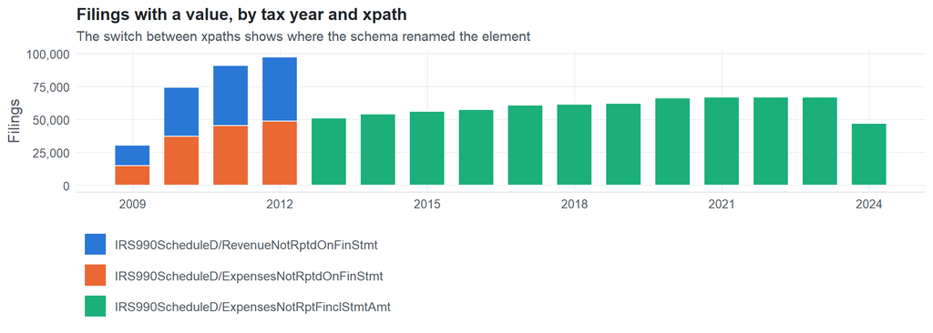

**Table view**

Table view: filings by tax year and series

| Tax year | IRS990ScheduleD/RevenueNotRptdOnFinStmt | IRS990ScheduleD/ExpensesNotRptdOnFinStmt | IRS990ScheduleD/ExpensesNotRptFinclStmtAmt |
| --- | --- | --- | --- |
| 2009 | 15,277 | 15,114 | 0 |
| 2010 | 37,356 | 37,131 | 0 |
| 2011 | 45,566 | 45,432 | 0 |
| 2012 | 48,698 | 48,600 | 0 |
| 2013 | 0 | 0 | 51,272 |
| 2014 | 0 | 0 | 54,244 |
| 2015 | 0 | 0 | 56,232 |
| 2016 | 0 | 0 | 57,411 |
| 2017 | 0 | 0 | 60,963 |
| 2018 | 0 | 0 | 61,650 |
| 2019 | 0 | 0 | 62,221 |
| 2020 | 0 | 0 | 66,273 |
| 2021 | 0 | 0 | 66,855 |
| 2022 | 0 | 0 | 66,996 |
| 2023 | 0 | 0 | 66,801 |
| 2024 | 0 | 0 | 47,102 |

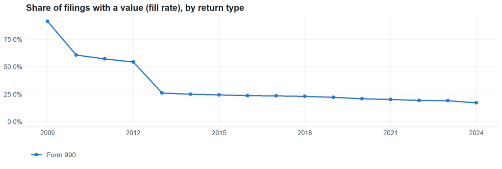

**Table view**

Table view: fill rate

| Tax year | Return type | Filings | All filings | Fill rate |
| --- | --- | --- | --- | --- |
| 2009 | Form 990 | 30,391 | 33,311 | 91.23% |
| 2010 | Form 990 | 74,487 | 123,025 | 60.55% |
| 2011 | Form 990 | 90,998 | 159,504 | 57.05% |
| 2012 | Form 990 | 97,298 | 179,688 | 54.15% |
| 2013 | Form 990 | 51,272 | 198,855 | 25.78% |
| 2014 | Form 990 | 54,244 | 218,619 | 24.81% |
| 2015 | Form 990 | 56,232 | 233,519 | 24.08% |
| 2016 | Form 990 | 57,411 | 243,903 | 23.54% |
| 2017 | Form 990 | 60,963 | 261,612 | 23.30% |
| 2018 | Form 990 | 61,650 | 271,442 | 22.71% |
| 2019 | Form 990 | 62,221 | 283,694 | 21.93% |
| 2020 | Form 990 | 66,273 | 320,342 | 20.69% |
| 2021 | Form 990 | 66,855 | 336,480 | 19.87% |
| 2022 | Form 990 | 66,996 | 349,055 | 19.19% |
| 2023 | Form 990 | 66,801 | 354,768 | 18.83% |
| 2024 | Form 990 | 47,102 | 277,298 | 16.99% |

## Values

| Result | Check | Detail |
| --- | --- | --- |
| ✓ pass | Values parse as numbers | 100.0% of values are numeric |
| ▲ warn | No sudden change in the median between adjacent years | largest change 31.7x (IRS990ScheduleD/ExpensesNotRptdOnFinStmt, 990, TY2010) |
| ▲ warn | Pooled xpaths are on the same scale (same return type) | medians differ 4.0x (990: IRS990ScheduleD/RevenueNotRptdOnFinStmt vs IRS990ScheduleD/ExpensesNotRptFinclStmtAmt) |
| ⓘ info | Sign convention | 3.7% of values are negative (fine for net amounts) |

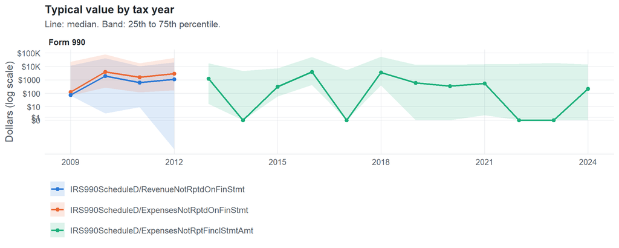

**Table view**

Table view: quartiles by tax year

| Series | Return | Tax year | Filings | P25 | Median | P75 |
| --- | --- | --- | --- | --- | --- | --- |
| IRS990ScheduleD/RevenueNotRptdOnFinStmt | 990 | 2009 | 15,277 | 68.44 | 73.89 | 11,257 |
| IRS990ScheduleD/RevenueNotRptdOnFinStmt | 990 | 2010 | 37,356 | 2.82 | 1,877 | 40,825 |
| IRS990ScheduleD/RevenueNotRptdOnFinStmt | 990 | 2011 | 45,566 | 9.23 | 635.60 | 10,401 |
| IRS990ScheduleD/RevenueNotRptdOnFinStmt | 990 | 2012 | 48,698 | -145.78 | 1,102 | 19,511 |
| IRS990ScheduleD/ExpensesNotRptdOnFinStmt | 990 | 2009 | 15,114 | 65.53 | 122.81 | 21,503 |
| IRS990ScheduleD/ExpensesNotRptdOnFinStmt | 990 | 2010 | 37,131 | 261.64 | 3,898 | 80,366 |
| IRS990ScheduleD/ExpensesNotRptdOnFinStmt | 990 | 2011 | 45,432 | 118.46 | 1,563 | 17,349 |
| IRS990ScheduleD/ExpensesNotRptdOnFinStmt | 990 | 2012 | 48,600 | 168.68 | 2,910 | 42,212 |
| IRS990ScheduleD/ExpensesNotRptFinclStmtAmt | 990 | 2013 | 51,272 | 16.01 | 1,239 | 16,966 |
| IRS990ScheduleD/ExpensesNotRptFinclStmtAmt | 990 | 2014 | 54,244 | 0 | 0 | 4,529 |
| IRS990ScheduleD/ExpensesNotRptFinclStmtAmt | 990 | 2015 | 56,232 | 57.77 | 311.64 | 7,262 |
| IRS990ScheduleD/ExpensesNotRptFinclStmtAmt | 990 | 2016 | 57,411 | 420.31 | 3,857 | 49,975 |
| IRS990ScheduleD/ExpensesNotRptFinclStmtAmt | 990 | 2017 | 60,963 | 0 | 0 | 5,194 |
| IRS990ScheduleD/ExpensesNotRptFinclStmtAmt | 990 | 2018 | 61,650 | 393.98 | 3,580 | 53,337 |
| IRS990ScheduleD/ExpensesNotRptFinclStmtAmt | 990 | 2019 | 62,221 | 0 | 607.41 | 13,447 |
| IRS990ScheduleD/ExpensesNotRptFinclStmtAmt | 990 | 2020 | 66,273 | 0 | 338.64 | 13,208 |
| IRS990ScheduleD/ExpensesNotRptFinclStmtAmt | 990 | 2021 | 66,855 | 1.86 | 543.42 | 14,487 |
| IRS990ScheduleD/ExpensesNotRptFinclStmtAmt | 990 | 2022 | 66,996 | 0 | 0 | 15,718 |
| IRS990ScheduleD/ExpensesNotRptFinclStmtAmt | 990 | 2023 | 66,801 | 0 | 0 | 18,132 |
| IRS990ScheduleD/ExpensesNotRptFinclStmtAmt | 990 | 2024 | 47,102 | 0 | 213.00 | 13,830 |

Summary by xpath and return type (all years)

| Series | Return | Filings | % numeric | % zero | % negative | Median (typical year) | P99 (typical year) |
| --- | --- | --- | --- | --- | --- | --- | --- |
| IRS990ScheduleD/RevenueNotRptdOnFinStmt | 990 | 146,897 | 100 | 64.8 | 10.8 | 0 | 24526181 |
| IRS990ScheduleD/ExpensesNotRptdOnFinStmt | 990 | 146,277 | 100 | 70.4 | 2.7 | 419 | 34700085 |
| IRS990ScheduleD/ExpensesNotRptFinclStmtAmt | 990 | 718,020 | 100 | 64.5 | 2.4 | 0 | 16578860 |

## Examples

| Tax year | Return | Xpath | Organization | Value | Source |
| --- | --- | --- | --- | --- | --- |
| 2024 | 990 | IRS990ScheduleD/ExpensesNotRptFinclStmtAmt | RISEWELL COMMUNITY SERVICES INC FKA | 0 | [XML](https://gt990datalake-rawdata.s3.amazonaws.com/EfileData/XmlFiles/202610589349301811_public.xml) |
| 2023 | 990 | IRS990ScheduleD/ExpensesNotRptFinclStmtAmt | ZEPF CENTER | 0 | [XML](https://gt990datalake-rawdata.s3.amazonaws.com/EfileData/XmlFiles/202423399349300887_public.xml) |
| 2022 | 990 | IRS990ScheduleD/ExpensesNotRptFinclStmtAmt | Providence Brown Street Housing | 0 | [XML](https://gt990datalake-rawdata.s3.amazonaws.com/EfileData/XmlFiles/202411239349300546_public.xml) |
| 2021 | 990 | IRS990ScheduleD/ExpensesNotRptFinclStmtAmt | VIRGINIA BEACH PUBLIC SCHOOLS | 3827 | [XML](https://gt990datalake-rawdata.s3.amazonaws.com/EfileData/XmlFiles/202310839349300011_public.xml) |
| 2020 | 990 | IRS990ScheduleD/ExpensesNotRptFinclStmtAmt | CHARLOTTE HARBOR WATER ASSOCIATION INC | 0 | [XML](https://gt990datalake-rawdata.s3.amazonaws.com/EfileData/XmlFiles/202132739349301608_public.xml) |
| 2019 | 990 | IRS990ScheduleD/ExpensesNotRptFinclStmtAmt | INDEPENDENCE IV INC | 0 | [XML](https://gt990datalake-rawdata.s3.amazonaws.com/EfileData/XmlFiles/202111349349304201_public.xml) |
| 2018 | 990 | IRS990ScheduleD/ExpensesNotRptFinclStmtAmt | EDUCATION SERVICE CENTER REGION XIII | 0 | [XML](https://gt990datalake-rawdata.s3.amazonaws.com/EfileData/XmlFiles/202041979349307389_public.xml) |
| 2017 | 990 | IRS990ScheduleD/ExpensesNotRptFinclStmtAmt | CAROLINA COUNTRY CLUB COMPANY | 0 | [XML](https://gt990datalake-rawdata.s3.amazonaws.com/EfileData/XmlFiles/201921929349300317_public.xml) |
| 2016 | 990 | IRS990ScheduleD/ExpensesNotRptFinclStmtAmt | TEXAS UNITED METHODIST COLLEGE ASSOC | 0 | [XML](https://gt990datalake-rawdata.s3.amazonaws.com/EfileData/XmlFiles/201742339349301054_public.xml) |
| 2015 | 990 | IRS990ScheduleD/ExpensesNotRptFinclStmtAmt | STAPELEY HALL | 119166 | [XML](https://gt990datalake-rawdata.s3.amazonaws.com/EfileData/XmlFiles/201623199349306982_public.xml) |
| 2014 | 990 | IRS990ScheduleD/ExpensesNotRptFinclStmtAmt | ROCHESTER AREA NEIGHBORHOOD HOUSE | 0 | [XML](https://gt990datalake-rawdata.s3.amazonaws.com/EfileData/XmlFiles/201543139349302224_public.xml) |
| 2013 | 990 | IRS990ScheduleD/ExpensesNotRptFinclStmtAmt | THE COUNCIL ON ALCOHOLISM & DRUG | 0 | [XML](https://gt990datalake-rawdata.s3.amazonaws.com/EfileData/XmlFiles/201441989349300024_public.xml) |

## Reviewer checklist

- The definition matches the form line and instructions for every xpath’s schema years.
- Every xpath pooled here measures the same thing on the 990 and 990-EZ (close enough for analysis).
- The coverage chart has no unexplained gaps or jumps between tax years.
- Each open flag is fixed, or accepted with a note in validation_log.csv.
- Values are whole dollars, not thousands, and not a percentage.
- Current year / prior year and beginning / end of year match the variable name (CY, PY, BOY, EOY).
- Negative values are expected only for net amounts (gains, net income, fund balances).
- The 990 and 990-EZ medians differ only as much as the filer populations do.

Record the review as a row in `inst/extdata/src/validation_log.csv` (variable_name, reviewer, date, status, note). Evidence built 2026-09-23 17:09:04 MST from the ef2 DuckDB builds (tax years 2009–2024).